# Coronavirus Exploratory Data Analysis

Zainab Sherani

03-14-20

# Set Up Libraries

```r
library(dplyr)
```

# Introduction

The coronavirus pandemic originated in Wuhan, China in December 2019 and has since spread throughout the world. As of March 14, there are 152,000 reported cases in 125 countries, and more than 5,700 deaths (New York Times, 2020).The disease is highly contagious and can spread by the droplets of a sick person when they talk, sneeze, or breathe. Symptoms can take two to 14 days to appear and include fevers, shortness of breath, and persistent chest pain (Sheikh et al., 2020). These symptoms vary in severity by age and health status and those over 60, and particularly those over 80, are the most vulnerable (Hafner, 2020). Since treatement to create a vaccine is at least a year away, everyone is encouraged to practice prevention to curtail its spread. Prevention strategies include washing hands, social-distancing, and avoiding touching one’s face (New York Times, 2020).

# Data Cleaning/ Preparation

In this step, the coronavirus and comorbidity data are read in. The coronavirus dataset is a subset of patients’ tested for Covid-19 around the world. It has columns identifying the patient, their age, coronavirus test result, country of origin, race, ethnicity, and death result. The comorbidity dataset includes a column for ID and a corresponding disease. The two datasets were merged by ID. Age values greater than or equal to 120 were considered implausible and recoded to NA. Additionally, any country values of “Mainland China” were essentially the same name for “China” and were therefore recoded to “China.”

```r
# Set working directory
setwd("/Users/zainabsherani/Desktop/INST408F/HW One")

# Load both files
cor <- read.csv("coronavirus.csv", header=T)
mor <- read.csv("comorbidity.csv", header=T)

# Merge the two datasets, keeping observations that exist in both files
corona <- inner_join(cor, mor, by="ID")

# Recode age values >= 120 to NA
corona$Age[corona$Age >= 120] <- NA

# Recode any values of ‘Mainland China’ to 'China'
corona$Country[corona$Country=="Mainland China"] <- "China"
```

# Exploratory Data Analysis

The dataset consisted of 1764 observations, 12 variables, and 49.9% of the patients in this dataset were female. 28 was the median age of those who tested postive, 28.4 was the mean age of patients who died from coronavirus, and the standard deviation of those who died from it was 15.9. This dataset consisted of 51.3%, 0.5%, and 10.1% of patients who tested positive from China, Italy, and the US, respectively. Of all patients who tested positive, 3.9% had Heart Disease, 7.5% had HIV, 1.9% had liver disease and 15.3% had Lupus.

```r
# Number of observations and variables
dim(corona)
```

```
## [1] 1764   12
```

```r
# Percentage of female patients
round(prop.table(table(corona$Sex == "F")) * 100, 1)
```

```
##
## FALSE  TRUE
##  50.1  49.9
```

```r
# Median age of patients who have coronavirus
round(median(corona$Age[corona$CoronaVirus == 1], na.rm=T), 1)
```

```
## [1] 28
```

```r
# Mean age of patients who died from coronavirus
round(mean(corona$Age[corona$Death == 1], na.rm=T), 1)
```

```
## [1] 28.4
```

```r
# Standard Deviation of patients who died from coronavirus
round(sd(corona$Age[corona$Death == 1], na.rm=T), 1)
```

```
## [1] 15.9
```

```r
# Percentage of patients with coronavirus from China, Italy, and the US
round(prop.table(table(corona$Country[corona$CoronaVirus == 1])) * 100, 1)
```

```
##
##            Australia              Belgium               Brazil
##                  4.5                  1.1                  0.0
##             Cambodia               Canada                China
##                  0.8                  3.7                 51.3
##                Egypt              Finland               France
##                  0.1                  1.3                  1.1
##              Germany            Hong Kong                India
##                  1.3                  1.3                  1.1
##                Italy          Ivory Coast                Japan
##                  0.5                  0.0                  1.5
##                Macau       Mainland China             Malaysia
##                  1.6                  0.0                  1.3
##               Mexico                Nepal              Nigeria
##                  0.0                  1.1                  0.0
##               Others          Philippines               Russia
##                  0.8                  0.9                  1.1
##            Singapore          South Korea                Spain
##                  1.5                  1.7                  0.7
##            Sri Lanka               Sweden               Taiwan
##                  0.9                  0.9                  2.1
##             Thailand                   UK United Arab Emirates
##                  1.5                  1.1                  1.5
##                   US              Vietnam
##                 10.1                  1.7
```

```r
# Comorbidities w/ percentages associated with patients who have coronavirus
round(prop.table(table(corona$Comorbidity[corona$CoronaVirus == 1])) * 100, 1)
```

```
##
## Heart Disease           HIV Liver Disease         Lupus          None
##           3.9           7.5           1.9          15.3          71.3
```

# Data visualization

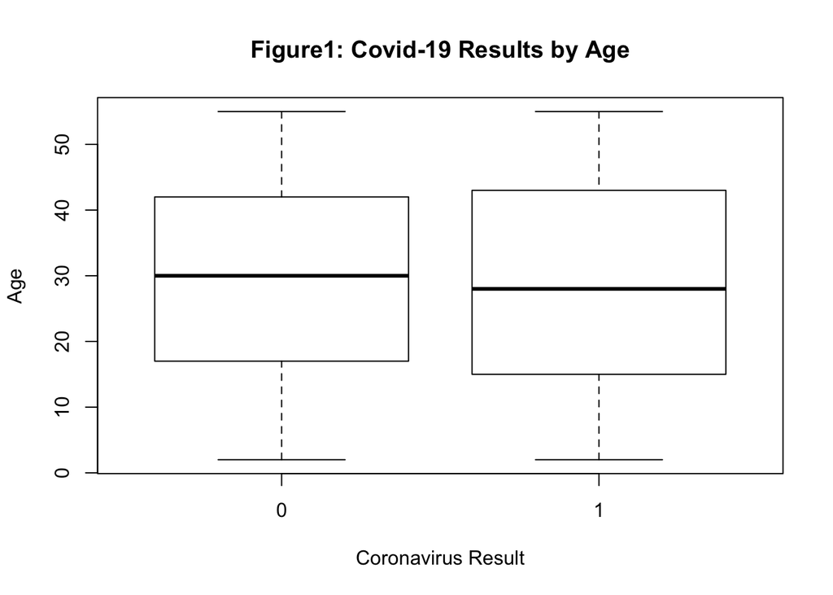

```r
# Create a boxplot of the age variable, by the coronavirus variable
plot <- boxplot(Age~CoronaVirus, data = corona,
                main="Figure1: Covid-19 Results by Age", xlab="Coronavirus Result", ylab ="Age")
```

# References

How Bad Will the Coronavirus Outbreak Get? Here Are 6 Key Factors - The New York Times. (n.d.). Retrieved March 15, 2020, from https://www.nytimes.com/interactive/2020/world/asia/china-coronavirus-contain.html?action=click&pgtype=Article&state=default&module=styln-coronavirus&variant=show&region=TOP_BANNER&context=storyline_menu#transmission

How to Protect Older People From the Coronavirus - The New York Times. (n.d.). Retrieved March 15, 2020, from https://www.nytimes.com/2020/03/14/health/coronavirus-elderly-protection.html

The Coronavirus Outbreak - The New York Times. (n.d.). Retrieved March 15, 2020, from https://www.nytimes.com/news-event/coronavirus